# ncRNA Heart Transplantation

## Data Import

**Importing Clinical Data**

| sample | condition | antibody |
| --- | --- | --- |
| 105_S1_R1_001 | NR | no |
| 166_S4_R1_001 | ACR | no |
| 144_S5_R1_001 | CAV | no |
| 135_S7_R1_001 | CAV | no |
| 128_S8_R1_001 | NR | no |
| 109_S9_R1_001 | NR | no |
| 187_S10_R1_001 | NR | no |
| 125_S11_R1_001 | NR | yes |
| 124_S16_R1_001 | ACR | no |
| 103_S17_R1_001 | ACR | no |

[output cut: 10 more lines]

**Importing Raw Counts**

```
                    105_S1_R1_001 166_S4_R1_001 144_S5_R1_001 135_S7_R1_001 128_S8_R1_001 109_S9_R1_001 187_S10_R1_001 125_S11_R1_001
hsa-let-7a-2-3p                 0             0             0             0             0             0              0              0
hsa-let-7a-3p                 151           289           132           257           236           207            150            447
hsa-let-7a-5p-7c-5p         70803         61240         44676        127638        142998        140091          73040         108998
hsa-let-7b-3p                 136           116           107           110            57            76            201            152
hsa-let-7b-5p               16746         10461         13828         19229         26730         21797          11771           8588
hsa-let-7c-3p                   0             0             0             0             0             0              0              0
                    124_S16_R1_001 103_S17_R1_001 123_S20_R1_001 192_S22_R1_001 167_S23_R1_001 121_S24_R1_001 182_S25_R1_001 179_S26_R1_001
hsa-let-7a-2-3p                  0              0              0              0              0              0              9              0
hsa-let-7a-3p                  213            200            273            264             19             92           1679            398
hsa-let-7a-5p-7c-5p          80045          60959          99114         140333          90917         143091          45963         105957
hsa-let-7b-3p                  140            136            146            165             43             37           1212            230
hsa-let-7b-5p                18048          12270          31399          37892          38677          53272          14348          19112
hsa-let-7c-3p                    0              0              5              0              0              0             59              0
                    112_S27_R1_001 106_S28_R1_001 138_S30_R1_001 127_S29_R1_001
hsa-let-7a-2-3p                  0              0              0              0
hsa-let-7a-3p                  202              5            691              0
hsa-let-7a-5p-7c-5p          85168          17338          53985          13235
hsa-let-7b-3p                  111              3            179              0
hsa-let-7b-5p                34271           8843          16421           5866
hsa-let-7c-3p                    0              0              0              0
```

**Importing Annotation Data:**

| Sample.name.s. | Filtered.miRNA.Reads | Hairpin.miRNAs | mature.tRNA.Reads | primary.tRNA.Reads | snoRNA.Reads | rRNA.Reads | ncRNA.others | mRNA.Reads |
| --- | --- | --- | --- | --- | --- | --- | --- | --- |
| 105_S1_R1_001 | 16771254 | 1611 | 44435 | 8 | 5799 | 118695 | 2440296 | 9796 |
| 166_S4_R1_001 | 25629332 | 1367 | 140585 | 58 | 17365 | 196654 | 1956829 | 14320 |
| 144_S5_R1_001 | 23203639 | 530 | 38313 | 3 | 3657 | 64129 | 860468 | 7757 |
| 135_S7_R1_001 | 26188565 | 1172 | 35388 | 33 | 6284 | 95207 | 1190436 | 8869 |
| 128_S8_R1_001 | 37265549 | 1304 | 44252 | 79 | 6578 | 63639 | 1823486 | 8583 |
| 109_S9_R1_001 | 23665139 | 872 | 60970 | 35 | 15279 | 97105 | 2023232 | 18166 |
| 187_S10_R1_001 | 16840522 | 1475 | 175725 | 51 | 8213 | 130111 | 2222013 | 43520 |
| 125_S11_R1_001 | 21501577 | 2151 | 60585 | 23 | 7114 | 153366 | 1188836 | 17749 |
| 124_S16_R1_001 | 30962515 | 1063 | 53091 | 25 | 5827 | 97539 | 2452828 | 10310 |
| 103_S17_R1_001 | 26669389 | 1311 | 55217 | 54 | 6534 | 102306 | 1615731 | 9673 |

[output cut: 10 more lines]

**Merging & Summarization** Calculating the sum of reads for each RNA type across every clinical condition (NR, ACR, AMR, CAV)

| condition | Filtered.miRNA.Reads | Hairpin.miRNAs | mature.tRNA.Reads | primary.tRNA.Reads | snoRNA.Reads | rRNA.Reads | ncRNA.others | mRNA.Reads |
| --- | --- | --- | --- | --- | --- | --- | --- | --- |
| ACR | 83261236 | 3741 | 248893 | 137 | 29726 | 396499 | 6025388 | 34303 |
| AMR | 76685089 | 5492 | 342556 | 122 | 67969 | 694800 | 11313041 | 105877 |
| CAV | 138278831 | 10021 | 323075 | 120 | 75169 | 861099 | 10816766 | 86327 |
| NR | 194475261 | 11799 | 618270 | 693 | 716989 | 1714869 | 20773446 | 424870 |

**Total read counts stratified by RNA type for each sample, Figure 1A** Generating a stacked bar plot of the absolute read counts (in millions) across various RNA biotypes for each sample, faceted by clinical group.

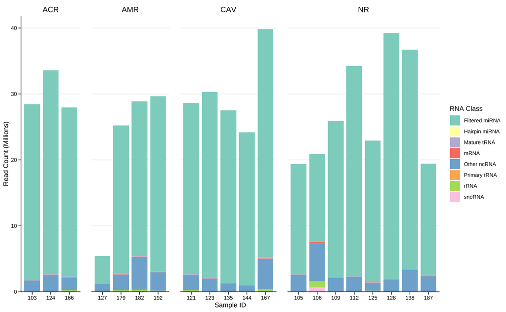

**Additional calculations** Computing the total sum of reads for each sample

|  | Sample.name.s. | Filtered.miRNA.Reads | Hairpin.miRNAs | mature.tRNA.Reads | primary.tRNA.Reads | snoRNA.Reads | rRNA.Reads | ncRNA.others | mRNA.Reads |
| --- | --- | --- | --- | --- | --- | --- | --- | --- | --- |
| 1 | 105_S1_R1_001 | 16771254 | 1611 | 44435 | 8 | 5799 | 118695 | 2440296 | 9796 |
| 2 | 166_S4_R1_001 | 25629332 | 1367 | 140585 | 58 | 17365 | 196654 | 1956829 | 14320 |
| 3 | 144_S5_R1_001 | 23203639 | 530 | 38313 | 3 | 3657 | 64129 | 860468 | 7757 |
| 4 | 135_S7_R1_001 | 26188565 | 1172 | 35388 | 33 | 6284 | 95207 | 1190436 | 8869 |
| 5 | 128_S8_R1_001 | 37265549 | 1304 | 44252 | 79 | 6578 | 63639 | 1823486 | 8583 |
| 6 | 109_S9_R1_001 | 23665139 | 872 | 60970 | 35 | 15279 | 97105 | 2023232 | 18166 |
| 7 | 187_S10_R1_001 | 16840522 | 1475 | 175725 | 51 | 8213 | 130111 | 2222013 | 43520 |
| 8 | 125_S11_R1_001 | 21501577 | 2151 | 60585 | 23 | 7114 | 153366 | 1188836 | 17749 |
| 9 | 124_S16_R1_001 | 30962515 | 1063 | 53091 | 25 | 5827 | 97539 | 2452828 | 10310 |
| 10 | 103_S17_R1_001 | 26669389 | 1311 | 55217 | 54 | 6534 | 102306 | 1615731 | 9673 |

[output cut: 11 more lines]

**Percentage Distribution of RNA Biotypes** Calculating the percentage of each small RNA class relative to the total number of reads in the entire experiment.

|  | Filtered.miRNA.Reads | Hairpin.miRNAs | mature.tRNA.Reads | primary.tRNA.Reads | snoRNA.Reads | rRNA.Reads | ncRNA.others | mRNA.Reads |
| --- | --- | --- | --- | --- | --- | --- | --- | --- |
| total | 89.84285 | 0.005662447 | 0.2795017 | 0.0001954769 | 0.1622628 | 0.6687182 | 8.922031 | 0.1187772 |

**Sequencing Depth per Group** Aggregating the total number of reads for each clinical group (used to describe cohort characteristics in the manuscript text).

| condition | total_reads |
| --- | --- |
| ACR | 89999923 |
| AMR | 89214946 |
| CAV | 150451408 |
| NR | 218736197 |

## Differential Expression Analysis

**Custom Functions for DESeq2 Automation** Creating two custom functions: *run_deseq_pipeline* — sets the reference group, applies a low-count filter (minimum of 10 reads in at least 3 samples), and runs the DESeq2 model. *extract_and_plot* — extracts comparison results, applies apeglm shrinkage for LFC correction, filters significant miRNAs, and generates a Volcano Plot.

### Pairwise Comparisons with the Normal Reference (NR as Reference)

**Differential expression analysis for Antibody-Mediated Rejection (AMR vs NR), Figure 2A**

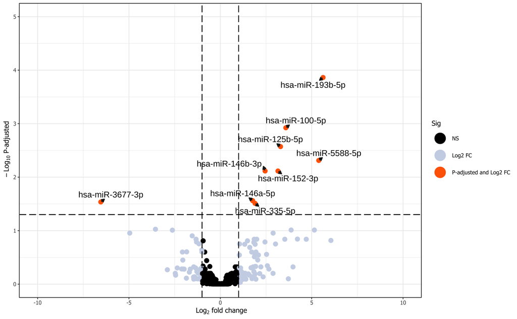

|  | baseMean | log2FoldChange | lfcSE | stat | pvalue | padj |
| --- | --- | --- | --- | --- | --- | --- |
| hsa-miR-100-5p | 1474.78255 | 3.584092 | 0.7926169 | 4.521847 | 6.130244e-06 | 0.0011923325 |
| hsa-miR-125b-5p | 426.32541 | 3.294506 | 0.7738426 | 4.257333 | 2.068801e-05 | 0.0026825457 |
| hsa-miR-146a-5p | 5344.62711 | 1.769101 | 0.5078480 | 3.483525 | 4.948567e-04 | 0.0274998952 |
| hsa-miR-146b-3p | 300.36136 | 2.449628 | 0.6344974 | 3.860737 | 1.130453e-04 | 0.0076706745 |
| hsa-miR-152-3p | 290.86888 | 3.153140 | 0.8190839 | 3.849594 | 1.183137e-04 | 0.0076706745 |
| hsa-miR-193b-5p | 206.21404 | 5.621551 | 1.1037210 | 5.093272 | 3.519368e-07 | 0.0001369034 |
| hsa-miR-335-5p | 919.95668 | 1.899823 | 0.5614182 | 3.383971 | 7.144560e-04 | 0.0308803753 |
| hsa-miR-3677-3p | 16.05159 | -6.541315 | 1.9057003 | -3.432499 | 5.980458e-04 | 0.0290799773 |
| hsa-miR-5588-5p | 93.25007 | 5.386293 | 1.3281772 | 4.055402 | 5.004812e-05 | 0.0048671795 |

|  | baseMean | log2FoldChange | lfcSE | pvalue | padj |
| --- | --- | --- | --- | --- | --- |
| hsa-miR-100-5p | 1474.78255 | 3.2444600 | 0.8018228 | 6.130244e-06 | 0.0011923325 |
| hsa-miR-125b-5p | 426.32541 | 2.9422036 | 0.7854339 | 2.068801e-05 | 0.0026825457 |
| hsa-miR-146a-5p | 5344.62711 | -1.2293550 | 0.5419588 | 4.948567e-04 | 0.0274998952 |
| hsa-miR-146b-3p | 300.36136 | -0.6535469 | 0.6012558 | 1.130453e-04 | 0.0076706745 |
| hsa-miR-152-3p | 290.86888 | 2.7369706 | 0.8373083 | 1.183137e-04 | 0.0076706745 |
| hsa-miR-193b-5p | 206.21404 | 5.1909341 | 1.1020520 | 3.519368e-07 | 0.0001369034 |
| hsa-miR-335-5p | 919.95668 | 1.6238231 | 0.5696835 | 7.144560e-04 | 0.0308803753 |
| hsa-miR-3677-3p | 16.05159 | -0.4370634 | 0.9066218 | 5.980458e-04 | 0.0290799773 |
| hsa-miR-5588-5p | 93.25007 | 4.7288451 | 1.3439445 | 5.004812e-05 | 0.0048671795 |

**Per-sample normalized expression of the principal candidate miRNAs across clinical groups, Figure 3**

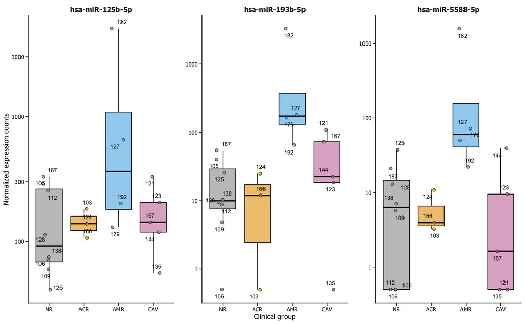

**Differential expression analysis for Acute Cellular Rejection (ACR vs NR)**

| baseMean | log2FoldChange | lfcSE | stat | pvalue | padj |
| --- | --- | --- | --- | --- | --- |

| baseMean | log2FoldChange | lfcSE | pvalue | padj |
| --- | --- | --- | --- | --- |

**Differential expression analysis for Cardiac Allograft Vasculopathy (CAV vs NR).**

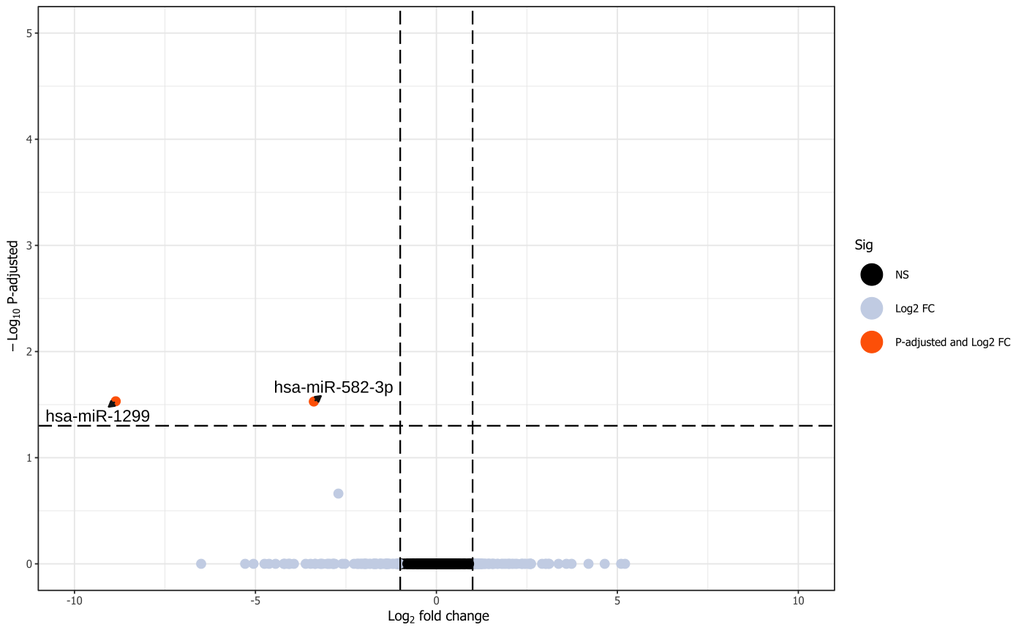

|  | baseMean | log2FoldChange | lfcSE | stat | pvalue | padj |
| --- | --- | --- | --- | --- | --- | --- |
| hsa-miR-1299 | 73.4441 | -8.860890 | 2.1823401 | -4.060270 | 4.901597e-05 | 0.02940958 |
| hsa-miR-582-3p | 1406.6345 | -3.387328 | 0.8698596 | -3.894108 | 9.856060e-05 | 0.02956818 |

|  | baseMean | log2FoldChange | lfcSE | pvalue | padj |
| --- | --- | --- | --- | --- | --- |
| hsa-miR-1299 | 73.4441 | -6.169870e-07 | 0.001442695 | 4.901597e-05 | 0.02940958 |
| hsa-miR-582-3p | 1406.6345 | -2.754192e-06 | 0.001442696 | 9.856060e-05 | 0.02956818 |

### Comparisons Between Rejection Types (ACR as Reference)

**Changing the baseline to ACR to identify differences between rejection types (AMR vs ACR), Figure 2D**

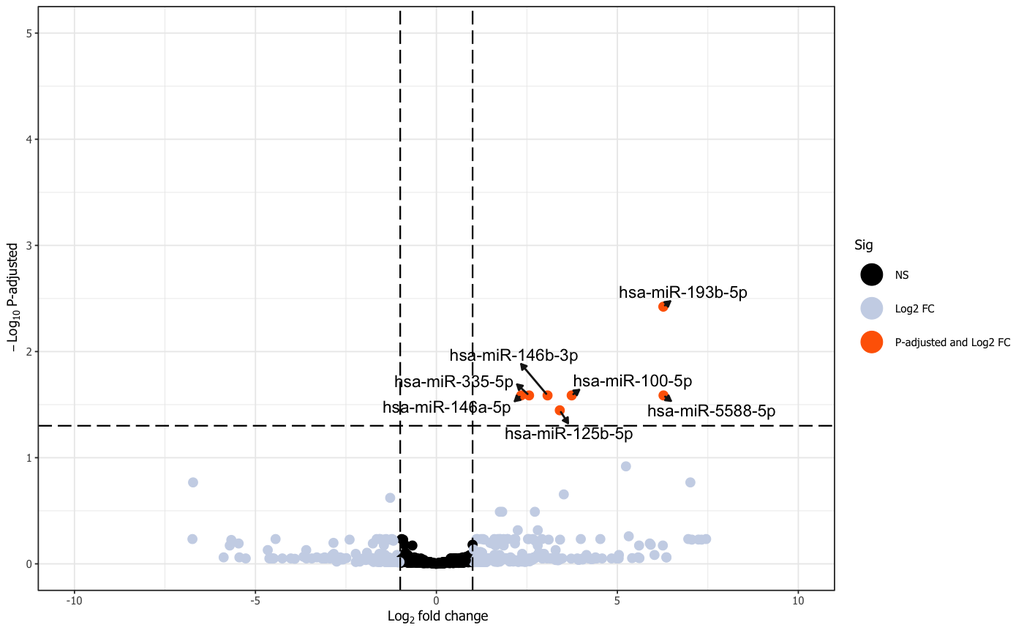

|  | baseMean | log2FoldChange | lfcSE | stat | pvalue | padj |
| --- | --- | --- | --- | --- | --- | --- |
| hsa-miR-100-5p | 1474.78255 | 3.737566 | 0.9888560 | 3.779687 | 1.570259e-04 | 0.025886683 |
| hsa-miR-125b-5p | 426.32541 | 3.408627 | 0.9659145 | 3.528911 | 4.172731e-04 | 0.035766270 |
| hsa-miR-146a-5p | 5344.62711 | 2.342284 | 0.6335080 | 3.697323 | 2.178852e-04 | 0.025886683 |
| hsa-miR-146b-3p | 300.36136 | 3.070913 | 0.7934626 | 3.870268 | 1.087157e-04 | 0.025886683 |
| hsa-miR-193b-5p | 206.21404 | 6.269361 | 1.3881619 | 4.516304 | 6.292825e-06 | 0.003775695 |
| hsa-miR-335-5p | 919.95668 | 2.560246 | 0.7007989 | 3.653324 | 2.588668e-04 | 0.025886683 |
| hsa-miR-5588-5p | 93.25007 | 6.275151 | 1.6799270 | 3.735372 | 1.874382e-04 | 0.025886683 |

|  | baseMean | log2FoldChange | lfcSE | pvalue | padj |
| --- | --- | --- | --- | --- | --- |
| hsa-miR-100-5p | 1474.78255 | 3.146908 | 1.1371650 | 1.570259e-04 | 0.025886683 |
| hsa-miR-125b-5p | 426.32541 | 2.780741 | 1.1344895 | 4.172731e-04 | 0.035766270 |
| hsa-miR-146a-5p | 5344.62711 | 2.002311 | 0.6902429 | 2.178852e-04 | 0.025886683 |
| hsa-miR-146b-3p | 300.36136 | 2.630990 | 0.8821514 | 1.087157e-04 | 0.025886683 |
| hsa-miR-193b-5p | 206.21404 | 5.567209 | 1.5702312 | 6.292825e-06 | 0.003775695 |
| hsa-miR-335-5p | 919.95668 | 2.166141 | 0.7743876 | 2.588668e-04 | 0.025886683 |
| hsa-miR-5588-5p | 93.25007 | 5.112907 | 2.1618903 | 1.874382e-04 | 0.025886683 |

**Changing the baseline to ACR to identify differences between rejection types (CAV vs ACR)**

| baseMean | log2FoldChange | lfcSE | stat | pvalue | padj |
| --- | --- | --- | --- | --- | --- |

| baseMean | log2FoldChange | lfcSE | pvalue | padj |
| --- | --- | --- | --- | --- |

### Pairwise Comparisons with CAV (CAV as Reference)

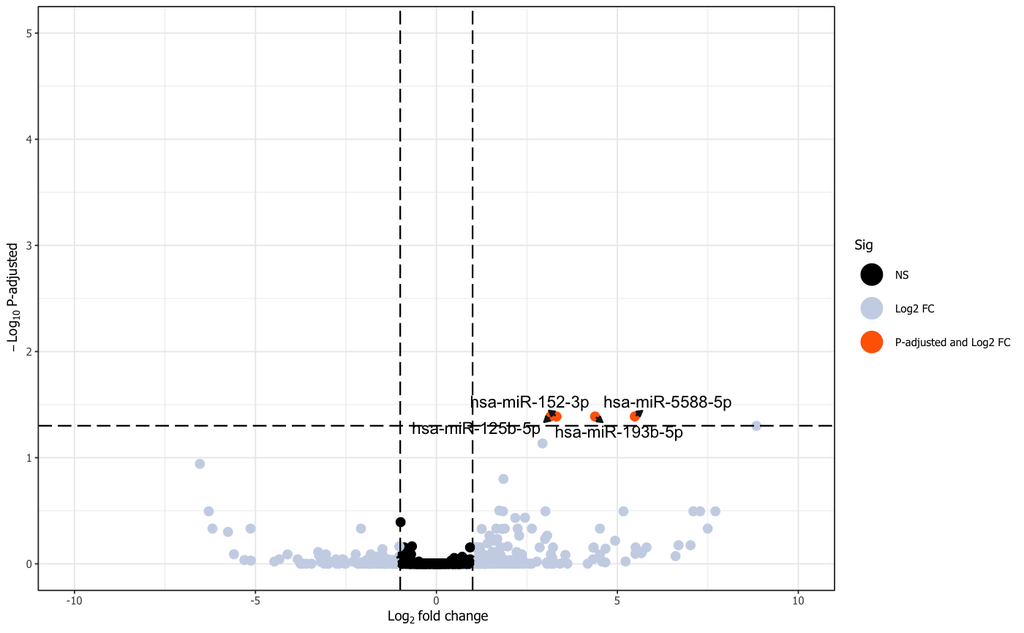

|  | baseMean | log2FoldChange | lfcSE | stat | pvalue | padj |
| --- | --- | --- | --- | --- | --- | --- |
| hsa-miR-125b-5p | 426.32541 | 3.148576 | 0.8474899 | 3.715179 | 0.0002030599 | 0.04088682 |
| hsa-miR-152-3p | 290.86888 | 3.319357 | 0.8973780 | 3.698950 | 0.0002164928 | 0.04088682 |
| hsa-miR-193b-5p | 206.21404 | 4.383945 | 1.2043621 | 3.640056 | 0.0002725788 | 0.04088682 |
| hsa-miR-5588-5p | 93.25007 | 5.481253 | 1.4556632 | 3.765468 | 0.0001662373 | 0.04088682 |

|  | baseMean | log2FoldChange | lfcSE | pvalue | padj |
| --- | --- | --- | --- | --- | --- |
| hsa-miR-125b-5p | 426.32541 | 2.658047 | 0.9177471 | 0.0002030599 | 0.04088682 |
| hsa-miR-152-3p | 290.86888 | 2.793943 | 0.9760412 | 0.0002164928 | 0.04088682 |
| hsa-miR-193b-5p | 206.21404 | 3.643651 | 1.3391342 | 0.0002725788 | 0.04088682 |
| hsa-miR-5588-5p | 93.25007 | 4.592788 | 1.6323084 | 0.0001662373 | 0.04088682 |

**Changing the baseline to CAV to evaluate ACR vs CAV**

| baseMean | log2FoldChange | lfcSE | stat | pvalue | padj |
| --- | --- | --- | --- | --- | --- |

| baseMean | log2FoldChange | lfcSE | pvalue | padj |
| --- | --- | --- | --- | --- |

### Covariate-Adjusted Model

**Adding antibody status (antibody) to the model design (~ antibody + condition) to account for the potential confounding effect of HLA sensitization on the expression profile, Figure 2C**

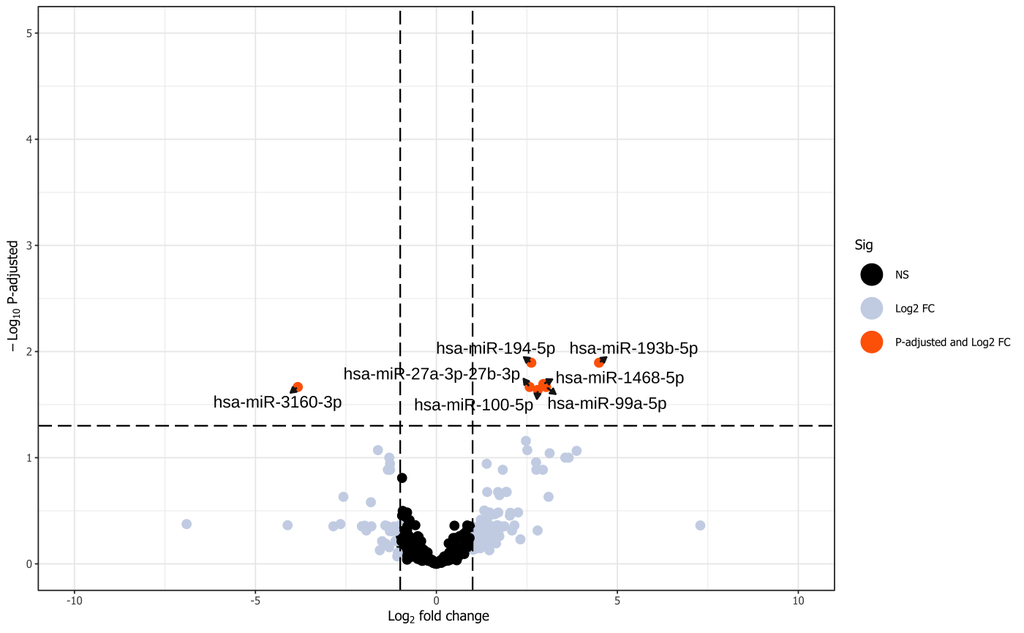

|  | baseMean | log2FoldChange | lfcSE | stat | pvalue | padj |
| --- | --- | --- | --- | --- | --- | --- |
| hsa-miR-100-5p | 1474.7826 | 2.801127 | 0.8008312 | 3.497775 | 4.691566e-04 | 0.02298867 |
| hsa-miR-1468-5p | 367.5035 | 2.952707 | 0.7874372 | 3.749769 | 1.769976e-04 | 0.02023672 |
| hsa-miR-193b-5p | 206.2140 | 4.492812 | 1.1096927 | 4.048699 | 5.150309e-05 | 0.01273665 |
| hsa-miR-194-5p | 990.5922 | 2.622212 | 0.6618091 | 3.962188 | 7.426616e-05 | 0.01273665 |
| hsa-miR-27a-3p-27b-3p | 223176.1189 | 2.576278 | 0.7245867 | 3.555514 | 3.772406e-04 | 0.02156559 |
| hsa-miR-3160-3p | 109.4773 | -3.830073 | 1.0508785 | -3.644640 | 2.677667e-04 | 0.02156559 |
| hsa-miR-99a-5p | 678.0566 | 3.031757 | 0.8514398 | 3.560741 | 3.698093e-04 | 0.02156559 |

|  | baseMean | log2FoldChange | lfcSE | pvalue | padj |
| --- | --- | --- | --- | --- | --- |
| hsa-miR-100-5p | 1474.7826 | 0.3213212 | 0.5522507 | 4.691566e-04 | 0.02298867 |
| hsa-miR-1468-5p | 367.5035 | 0.4140750 | 0.6685373 | 1.769976e-04 | 0.02023672 |
| hsa-miR-193b-5p | 206.2140 | 2.8972054 | 1.9047628 | 5.150309e-05 | 0.01273665 |
| hsa-miR-194-5p | 990.5922 | 1.6267753 | 1.2094640 | 7.426616e-05 | 0.01273665 |
| hsa-miR-27a-3p-27b-3p | 223176.1189 | 1.7979669 | 1.4918357 | 3.772406e-04 | 0.02156559 |
| hsa-miR-3160-3p | 109.4773 | -3.1062172 | 1.2911761 | 2.677667e-04 | 0.02156559 |
| hsa-miR-99a-5p | 678.0566 | 0.4250333 | 0.6933178 | 3.698093e-04 | 0.02156559 |

## Venn Diagram

**Venn diagram showing the overlap of filtered miRNAs among the clinical groups, Figure 1D** Applying a global noise filter to the raw counts and identifying the lists of miRNAs confidently expressed in each clinical group to build an intersection diagram

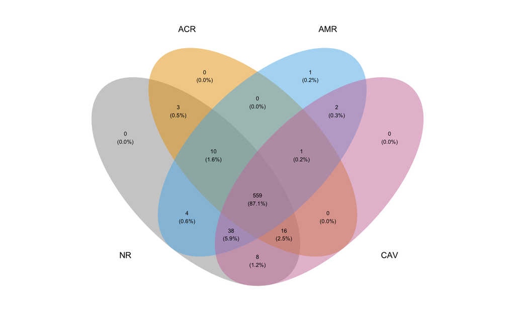

## Unsupervised Clustering & PCA

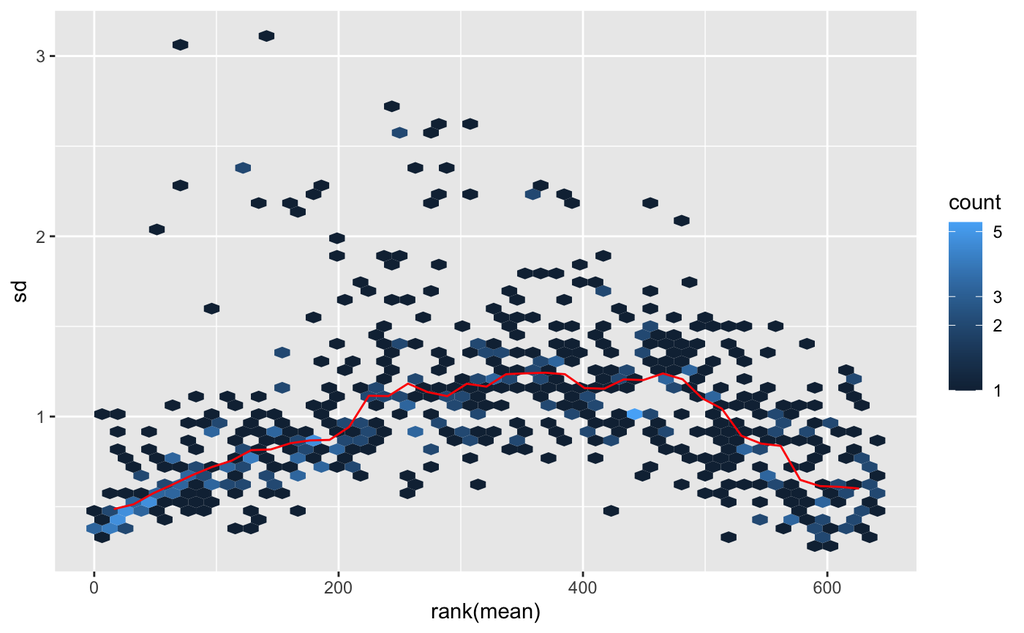

## Principal Component Analysis (PCA)

**Principal component analysis (PCA) of filtered miRNA expression profiles according to clinical group and the presence of contemporaneous anti-HLAs, Figure 1B** Generating a PCA plot to evaluate the global segregation of samples in a 2D space based on their expression profiles. Colors encode the clinical group, and shapes represent the antibody status

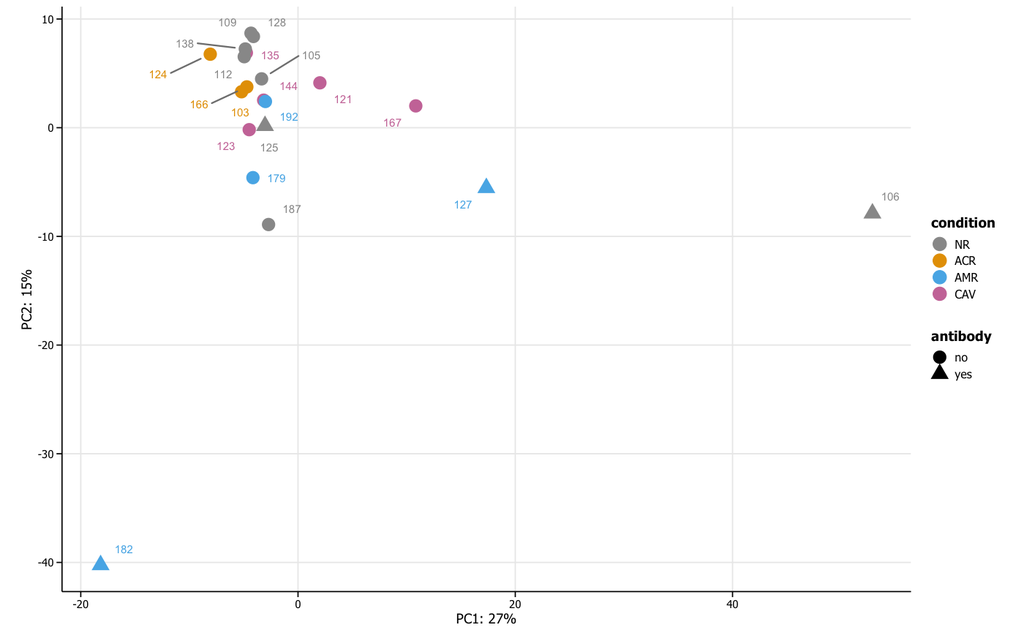

## Sample Distance Heatmap

**Distance-based heatmap of inter-sample correlations, annotated by clinical group and contemporaneous anti-HLA antibody status, Figure 1C** Calculating the Euclidean distance between all samples and generating a heatmap with hierarchical clustering to visualize patient similarities

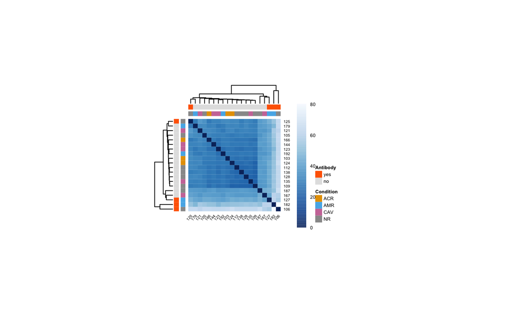

## Likelihood Ratio Test

**Multi-Group Analysis (LRT). Performing a Likelihood Ratio Test comparing the full model (~ condition) against an intercept-only reduced model (~ 1) to identify miRNAs whose expression significantly changes in at least one group compared to all others.**

```
out of 642 with nonzero total read count
adjusted p-value < 0.05
LFC > 0 (up)       : 6, 0.93%
LFC < 0 (down)     : 2, 0.31%
outliers [1]       : 42, 6.5%
low counts [2]     : 0, 0%
(mean count < 1)
[1] see 'cooksCutoff' argument of ?results
[2] see 'independentFiltering' argument of ?results
```

|  | baseMean | log2FoldChange | lfcSE | stat | pvalue | padj |
| --- | --- | --- | --- | --- | --- | --- |
| hsa-miR-100-5p | 1474.78255 | 0.6529607 | 0.7382176 | 30.21688 | 1.242431e-06 | 0.0003727294 |
| hsa-miR-125b-5p | 426.32541 | 0.1459306 | 0.7217727 | 28.76208 | 2.512614e-06 | 0.0005025227 |
| hsa-miR-146a-5p | 5344.62711 | 1.2443816 | 0.4727782 | 20.86453 | 1.123207e-04 | 0.0096274859 |
| hsa-miR-146b-3p | 300.36136 | 0.6102375 | 0.5915437 | 23.08622 | 3.874595e-05 | 0.0038745954 |
| hsa-miR-152-3p | 290.86888 | -0.1662154 | 0.7647217 | 23.46497 | 3.230319e-05 | 0.0038745954 |
| hsa-miR-193b-5p | 206.21404 | 1.2376087 | 1.0321941 | 37.78878 | 3.133000e-08 | 0.0000187980 |
| hsa-miR-335-5p | 919.95668 | 0.1625046 | 0.5229418 | 19.46120 | 2.194745e-04 | 0.0164605857 |
| hsa-miR-5588-5p | 93.25007 | -0.0949621 | 1.2526746 | 27.91035 | 3.792859e-06 | 0.0005689289 |

**Combined Figure 1**

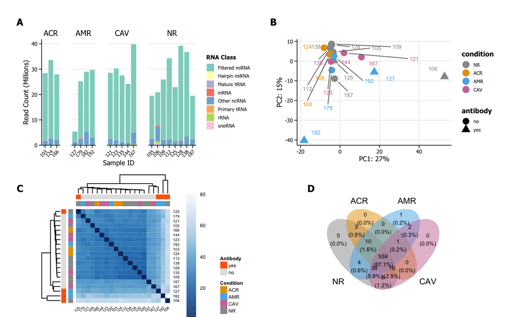

**Combined Figure 2**

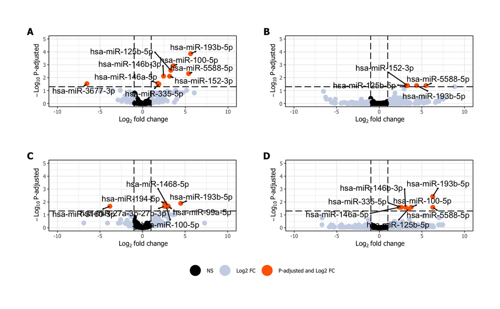